# 4. Annex on non-stunning interventions

Author

Sagar Shah, Rethink Priorities

Published

February 7, 2024

# Generic prep

Run code to load useful montecarlo simulation functions and general seabream seabass assumptions

```r
#Useful monte carlo functions
source("0a Useful functions.R")
source("0b Assumptions for seabream,seabass and trout.R")
source("0c  Modelling assumptions.R")
```

# Modelling assumptions

Define parameters over which to calculate share of simulation results. Definition of xvar provided in the table below.

| Approach | Meaning of ‘xvar’ variable means in context of calculations |
| --- | --- |
| Moral Value | Moral value of improving fish welfare for 1 year through intervention relative to gaining 1 DALY |
| Welfare Range | Welfare gain from intervention **-** expressed as % of entire fish welfare range (negative to positive |

```r
# Share of fish life affected by welfare intervention
  fishlifeshare_values <- c(0.01,0.02,0.05,0.10,0.15,0.25,0.35,0.50)

# Moral value points
  mv_table_values <- c(0.01,0.05,0.1,0.25,0.5,0.75,1,5,10,25)

# Moral value points
  wr_table_values <- c(0.001,0.01,0.025,0.5,0.1,0.15,0.35,0.5,0.75,0.9,1)
```

# Calculations

## Helper functions

Write helper functions to call object/vectors

```r
consumption <- function(country,species)  obtain(species,country,"tons")
mshare <- function(country) obtain("mshare_welfare",country)
psuccess <- function() get("psuccess_welfare")
weight <- function(species) obtain("weight",species)
lifexp <- function(species) obtain("lifexp",species)
cost <- function() get("cost_welfare")
stun_share <- function(species) obtain(species,"stunned")
```

## Number of fish affected/$ and associated lifespan

### Core calculation functions

Calculate number of fish affected per dollar spent

```r
# Number of fish affected per dollar
no_fish_affected <- function(country,species) {
consumption(country,species)*1E3/
  weight(species)*
  mshare(country)*
  psuccess()*
  stun_share(species)*
  years_credit*
  implementation_discount*
  fish_grocery
}
```

Life span of affected fish

```r
# Fish years of affected fish}
lifespan_affected_fish <- function(country,species) {
no_fish_affected(country,species)*lifexp(species)/12
}
```

### Execution functions

Produce a table that produces every possible combination of country and species, and a list of functions over which to calculate results.

```r
no_of_countries <- length(country_list)
country_species <- expand.grid(country=country_list,species=species_list)
measure_list <- c("lifespan_affected_fish","no_fish_affected")
```

I now write a function that calculates number of fish / lifespan affected per country/species pair, sums across all the country/species pairs, and then divides by costs across all countries.

```r
output_per_dollar <- function(fish_function) {

      pmap(                           # Allows repeated calcs across different input vectors
          country_species,                # Input vector 1: countries to run function over
          get(fish_function)            # Calculation function (no of fish or minutes)
                ) %>%
       as.data.frame() %>%                  # Convert to data.frame
       mutate(
         total=rowSums(.)) %>%              # Work out sum of all country and species combinations
       pull(total)/(no_of_countries*cost()) # Divide by costs across all countries

}
```

I then produce tables with montecarlo simulation results for each measure in both wide and long format.

```r
impact_per_dollar_wide <- map(measure_list,output_per_dollar) %>%
                              set_names(measure_list) %>%
                              as.data.frame()

impact_per_dollar_long <-  impact_per_dollar_wide %>%
                            pivot_longer(
                                cols=1:length(measure_list),
                                names_to="description",
                                values_to="number")
```

Finally I produce a vector called fypd, that calculates the lifespan of affected fish, which is needed in the $/DALY and share of simulation results.

```r
fypd <- output_per_dollar("lifespan_affected_fish")
```

## $/DALY results

### Core calculation functions

```r
results_dollar_per_daly <-
   1/(
    fypd*
    salmon_wr*
    interventionlifesshare*
    fish_welfarerange_impact/
    DALY_share_of_welfare_range) %>%
    tibble() %>%
    set_names("dollars_per_daly")
```

## Share of simulations beating $$/DALY benchmark

### Core calculation functions

```r
#Moral value approach
share_mv <- function(xvar,fishlifeshare,bar) {
  mean(bar>(1/(fypd*fishlifeshare*xvar)))
}

# Welfare range approach
share_wr <- function(xvar,fishlifeshare,bar) {
  mean(bar>
      (1/
        (xvar*
        fypd*
        fishlifeshare*
        salmon_wr/
        DALY_share_of_welfare_range
        )))
}
```

### Calculations

Define xvar (moral value or welfare range) values for calculating share of simulations beating a particular $/DALY bar and create combinations of xvar values, bar values and, lifeshare values over which to calculate results.

```r
 chart_values<- 10^seq(-4,4,0.01)
  xvar_values <- c(chart_values,mv_table_values,wr_table_values)

share_sims_calculation_grid <-   expand_grid(
                                    xvar=xvar_values,
                                    bar=bar_values,
                                    fishlifeshare=fishlifeshare_values)
```

Calculate results

```r
share_sims_results_table <-
# Generate one row for unique combination of xvar_values and scenario lists
  share_sims_calculation_grid %>%
# Core calcualtions using share_mv and share_wr calculation functions
    rowwise() %>%
    mutate(
      moral_value=share_mv(xvar,fishlifeshare,bar),
      welfare_range=share_wr(xvar,fishlifeshare,bar)
    )
```

Format results table

```r
share_sims_results_table %<>%
# Convert pivot into longer format to make results easier to plot
  pivot_longer(
    cols=c(moral_value,welfare_range),
    names_to="approach",
    values_to="share_of_simulations") %>%
# Change descriptions of variables to make results easier to interpert
  mutate(
    approach=str_to_sentence(str_replace_all(approach,"_"," ")),
    bar_factor=factor(bar,levels=bar_values,labels=c("50","1K","70K")),
    fishlifeshare_factor=factor(fishlifeshare,levels=rev(fishlifeshare_values),labels=paste0(rev(fishlifeshare_values)*100,"%")))
```

# Results tables/charts production functions

## Impact per dollar density plots

```r
# Code to create impact per dollar density plot

impact_density_plot <- function(desired_filter,named_description) {
  impact_per_dollar_long %>%
  filter(description==desired_filter) %>%
  ggplot(
    aes(
      x=number
    )
  ) +
  geom_density() +
  theme_light() +
  scale_x_log10(labels = scales::comma_format(drop0trailing = TRUE),n.breaks=8) +
    labs(
    title=named_description,
    y="Probability density",
    x=paste0(named_description," (log scale)"))
}
```

## Share of simulations

Chart labels

```r
xlab_wr="
    Welfare gain from intervention as a % of total fish welfare range"

xlab_mv="Moral value of improving a fish life year via intervention
relative to gaining a human DALY"
```

Chart function

```r
share_sims_chart <- function (
                        chart_approach,
                        xvar_lower_lim=0,
                        xvar_upper_lim=max(xvar_values),
                        xlab_des,
                        bar_value=50
                        ) {

share_sims_results_table %>%
    filter(
    approach==chart_approach,
    xvar<=xvar_upper_lim,
    xvar>=xvar_lower_lim,
    bar==bar_value
    ) %>%
  ggplot(
    aes(
      x=xvar,
      y=share_of_simulations,
      color=fishlifeshare_factor))+
  geom_line()+
  scale_color_brewer(palette = "Dark2") +
  theme_light()+
  labs(
    subtitle = str_to_title(paste0(chart_approach," approach")),
    title=paste0("Share of simulations where intervention beats ",bar_value,"$/DALY benchmark"),
    y="Share of simulations",
    x=xlab_des,
    linetype="$/DALY Benchmark",
    color="Share of fish \nlifespan affected \nby intervention",
    caption= "Note log scale on x-axis")
}
```

Table function

```r
share_beating_bar_table <- function(values,chart_approach,bar_value) {

share_sims_results_table %>%
  filter(
      xvar %in% values,
      fishlifeshare %in% fishlifeshare_values,
      bar==bar_value,
      approach==chart_approach) %>%
      select(xvar,share_of_simulations,fishlifeshare_factor) %>%
      distinct() %>%
      pivot_wider(id_cols=xvar,names_from=fishlifeshare_factor,values_from=share_of_simulations) %>%
      arrange(xvar) %>%
      gt() %>%
      tab_header(title = paste0("Share of simulations beating $",bar_value,"/DALY bar")) %>%
      tab_spanner(label="Share of fish lifespan affected by intervention",columns=paste0(fishlifeshare_values*100,"%"))
}

wr_bar_table <- function(bar_value) {
  share_beating_bar_table(wr_table_values,"Welfare range",bar_value) %>%
  fmt_percent(decimals=1) %>%
  fmt_percent(columns=xvar,decimals=0) %>%
  cols_label(xvar=xlab_wr)
}

mv_bar_table <- function(bar_value) {
  share_beating_bar_table(mv_table_values,"Moral value",bar_value) %>%
  fmt_percent(decimals=1) %>%
  fmt_number(columns=xvar,drop_trailing_zeros=TRUE) %>%
  cols_label(xvar=xlab_mv)
}
```

# Outputs

## Impact per dollar

Density plot: number of fish affected

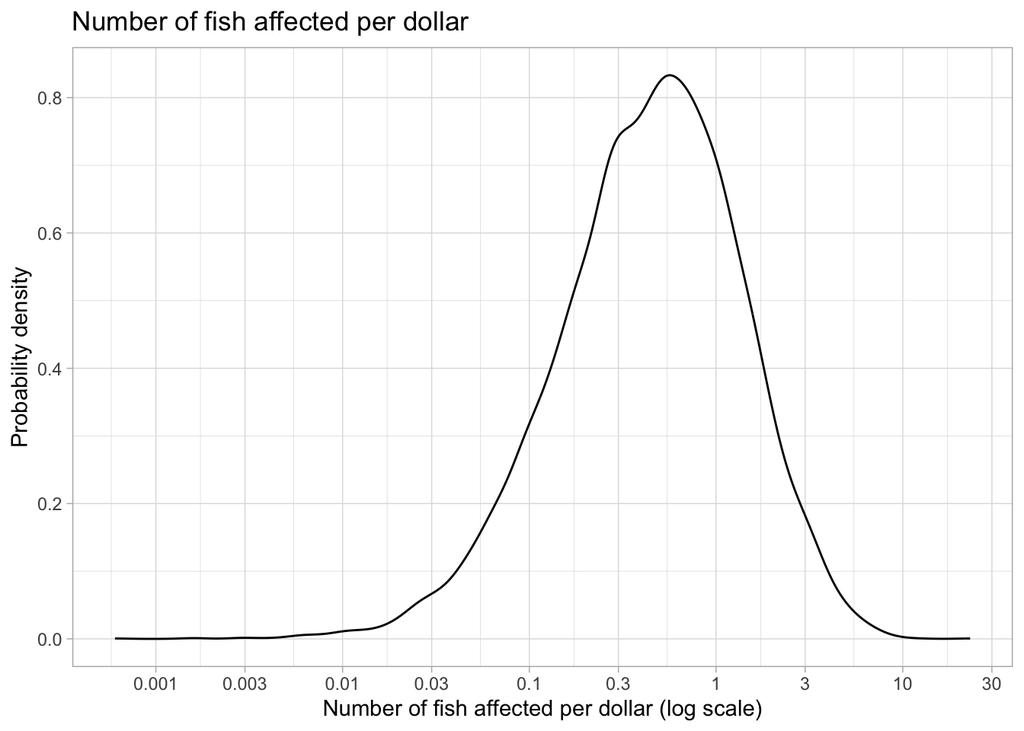

```r
impact_density_plot("no_fish_affected","Number of fish affected per dollar")
```

Density plot: lifespan of fish affected

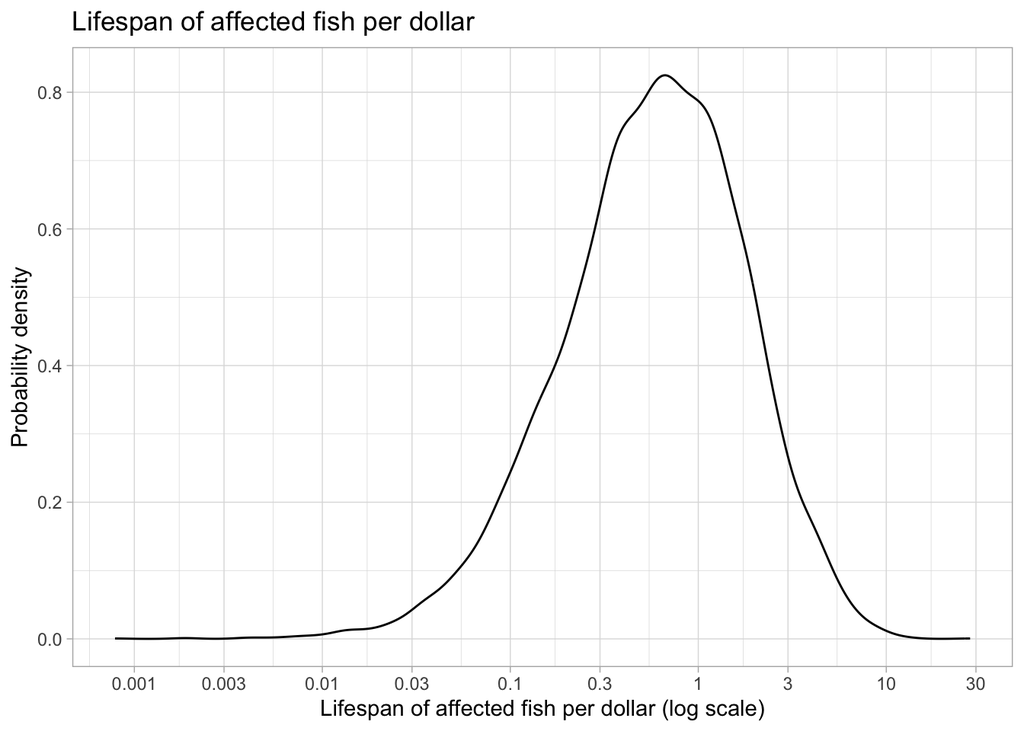

```r
impact_density_plot("lifespan_affected_fish","Lifespan of affected fish per dollar")
```

Results table

```r
tab_a22_impact_per_dollar_nonstunning <- summarystats(impact_per_dollar_wide)
tab_a22_impact_per_dollar_nonstunning
```

| statistic | lifespan_affected_fish | no_fish_affected |
| --- | --- | --- |
| mean | 0.973 | 0.748 |
| sd | 1.15 | 0.892 |
| median | 0.607 | 0.468 |
| p5 | 0.0795 | 0.0608 |
| p10 | 0.127 | 0.0972 |
| p25 | 0.280 | 0.214 |
| p75 | 1.24 | 0.949 |
| p90 | 2.19 | 1.69 |
| p95 | 3.08 | 2.41 |

## $/DALY approach

Summary stats

```r
summarystats(results_dollar_per_daly)
```

| statistic | dollars_per_daly |
| --- | --- |
| mean | 66.7M |
| sd | 2.21B |
| median | 2.41K |
| p5 | 88.6 |
| p10 | 158 |
| p25 | 507 |
| p75 | 18.1K |
| p90 | 218K |
| p95 | 1.23M |

Density plot

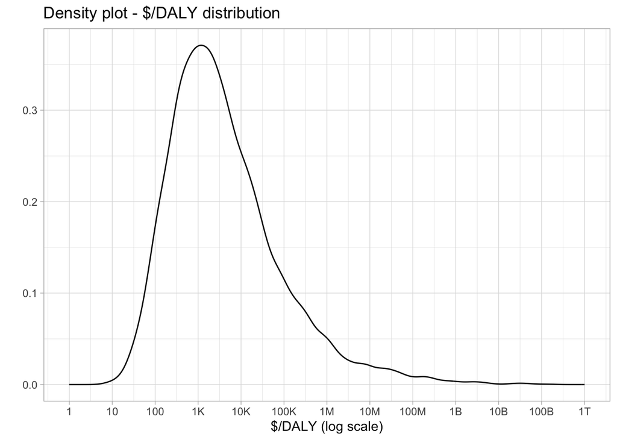

```r
fig_a21_dollars_per_daly_nonstunning <- densplotv(results_dollar_per_daly$dollars_per_daly)+
    scale_x_log10(
      limits=c(1,1E12),
      labels = scales::label_number_si(),
      n.breaks=15)+
    labs(
      title="Density plot - $/DALY distribution",
      y="",
      x="$/DALY (log scale)")

fig_a21_dollars_per_daly_nonstunning
```

Share beating bar

```r
share_below_bar <- function(bar_value) (mean(results_dollar_per_daly<bar_value))

tibble(
  `$/DALY bar`=bar_values,
  `Share beating bar`=map_vec(bar_values,share_below_bar)) %>%
  gt() %>%
  fmt_percent(columns=`Share beating bar`,decimals =1 )
```

| $/DALY bar | Share beating bar |
| --- | --- |
| 50 | 2.0% |
| 1000 | 35.9% |
| 70000 | 84.6% |

## Share of simulations beating bar

Share of simulation chart: welfare range

```r
fig_a22_50benchmark_wv_nonstunning <-
share_sims_chart("Welfare range",bar_value=50,xvar_lower_lim=0.01,xvar_upper_lim=1,xlab_des=xlab_wr)+
  scale_x_log10(labels = scales::percent_format(drop0trailing = TRUE),n.breaks=10)+
  scale_y_continuous(limits=c(0,0.75),n.breaks=10,labels = scales::percent_format(accuracy = 1))
```

Share of simulation chart: moral value

```r
fig_a23_50benchmark_mv_nonstunning <-
  share_sims_chart("Moral value",bar_value=50,xvar_lower_lim=0.001,xvar_upper_lim=30,xlab_des=xlab_mv)+
  scale_x_log10(labels = scales::label_number_si(drop0trailing = TRUE),n.breaks=11)+
  scale_y_continuous(limits=c(0,1),n.breaks=10,labels = scales::percent_format(accuracy = 1))
```

Share of simulation results tables: $50/DALY benchmark - welfare range

```r
wr_bar_table(50)
```

Share of simulations beating $50/DALY bar

| Welfare gain from intervention as a % of total fish welfare range | Share of fish lifespan affected by intervention 1% | Share of fish lifespan affected by intervention 2% | Share of fish lifespan affected by intervention 5% | Share of fish lifespan affected by intervention 10% | Share of fish lifespan affected by intervention 15% | Share of fish lifespan affected by intervention 25% | Share of fish lifespan affected by intervention 35% | Share of fish lifespan affected by intervention 50% |
| --- | --- | --- | --- | --- | --- | --- | --- | --- |
| 0% | 0.0% | 0.0% | 0.0% | 0.0% | 0.0% | 0.0% | 0.0% | 0.0% |
| 1% | 0.0% | 0.0% | 0.0% | 0.0% | 0.0% | 0.0% | 0.2% | 0.4% |
| 2% | 0.0% | 0.0% | 0.0% | 0.0% | 0.2% | 0.7% | 1.4% | 2.8% |
| 10% | 0.0% | 0.0% | 0.4% | 1.8% | 4.0% | 8.2% | 12.1% | 17.0% |
| 15% | 0.0% | 0.1% | 1.0% | 4.0% | 7.2% | 13.0% | 17.8% | 23.3% |
| 35% | 0.2% | 0.9% | 5.0% | 12.1% | 17.8% | 25.9% | 31.2% | 37.3% |
| 50% | 0.4% | 1.8% | 8.2% | 17.0% | 23.3% | 31.4% | 37.3% | 43.8% |
| 75% | 1.0% | 4.0% | 13.0% | 23.3% | 29.8% | 38.6% | 44.6% | 50.5% |
| 90% | 1.5% | 5.3% | 15.6% | 26.3% | 32.7% | 41.7% | 47.5% | 53.4% |
| 100% | 1.8% | 6.2% | 17.0% | 28.1% | 34.6% | 43.8% | 49.3% | 55.0% |

Share of simulation results tables: $50/DALY benchmark - moral value

```r
mv_bar_table(50)
```

Share of simulations beating $50/DALY bar

| Moral value of improving a fish life year via intervention relative to gaining a human DALY | Share of fish lifespan affected by intervention 1% | Share of fish lifespan affected by intervention 2% | Share of fish lifespan affected by intervention 5% | Share of fish lifespan affected by intervention 10% | Share of fish lifespan affected by intervention 15% | Share of fish lifespan affected by intervention 25% | Share of fish lifespan affected by intervention 35% | Share of fish lifespan affected by intervention 50% |
| --- | --- | --- | --- | --- | --- | --- | --- | --- |
| 0.01 | 0.0% | 0.0% | 0.0% | 0.0% | 0.0% | 0.2% | 0.9% | 2.8% |
| 0.05 | 0.0% | 0.0% | 0.2% | 2.8% | 6.9% | 17.5% | 27.8% | 40.0% |
| 0.1 | 0.0% | 0.1% | 2.8% | 11.8% | 22.6% | 40.0% | 52.2% | 64.3% |
| 0.25 | 0.2% | 2.8% | 17.5% | 40.0% | 54.8% | 71.6% | 79.7% | 86.5% |
| 0.5 | 2.8% | 11.8% | 40.0% | 64.3% | 76.2% | 86.5% | 91.4% | 95.0% |
| 0.75 | 6.9% | 22.6% | 54.8% | 76.2% | 84.6% | 92.2% | 95.2% | 97.3% |
| 1 | 11.8% | 32.5% | 64.3% | 82.6% | 89.2% | 95.0% | 96.9% | 98.3% |
| 5 | 64.3% | 82.6% | 95.0% | 98.3% | 99.2% | 99.6% | 99.8% | 99.9% |
| 10 | 82.6% | 92.8% | 98.3% | 99.5% | 99.7% | 99.9% | 99.9% | 100.0% |
| 25 | 95.0% | 98.3% | 99.6% | 99.9% | 99.9% | 100.0% | 100.0% | 100.0% |

Share of simulations - other results (not published in the main document)

```r
mv_bar_table(1000)
```

Share of simulations beating $1000/DALY bar

| Moral value of improving a fish life year via intervention relative to gaining a human DALY | Share of fish lifespan affected by intervention 1% | Share of fish lifespan affected by intervention 2% | Share of fish lifespan affected by intervention 5% | Share of fish lifespan affected by intervention 10% | Share of fish lifespan affected by intervention 15% | Share of fish lifespan affected by intervention 25% | Share of fish lifespan affected by intervention 35% | Share of fish lifespan affected by intervention 50% |
| --- | --- | --- | --- | --- | --- | --- | --- | --- |
| 0.01 | 0.1% | 1.4% | 11.8% | 32.5% | 46.7% | 64.3% | 74.5% | 82.6% |
| 0.05 | 11.8% | 32.5% | 64.3% | 82.6% | 89.2% | 95.0% | 96.9% | 98.3% |
| 0.1 | 32.5% | 56.9% | 82.6% | 92.8% | 96.2% | 98.3% | 99.1% | 99.5% |
| 0.25 | 64.3% | 82.6% | 95.0% | 98.3% | 99.2% | 99.6% | 99.8% | 99.9% |
| 0.5 | 82.6% | 92.8% | 98.3% | 99.5% | 99.7% | 99.9% | 99.9% | 100.0% |
| 0.75 | 89.2% | 96.2% | 99.2% | 99.7% | 99.8% | 99.9% | 100.0% | 100.0% |
| 1 | 92.8% | 97.6% | 99.5% | 99.8% | 99.9% | 100.0% | 100.0% | 100.0% |
| 5 | 99.5% | 99.8% | 100.0% | 100.0% | 100.0% | 100.0% | 100.0% | 100.0% |
| 10 | 99.8% | 99.9% | 100.0% | 100.0% | 100.0% | 100.0% | 100.0% | 100.0% |
| 25 | 100.0% | 100.0% | 100.0% | 100.0% | 100.0% | 100.0% | 100.0% | 100.0% |

```r
mv_bar_table(70000)
```

Share of simulations beating $70000/DALY bar

| Moral value of improving a fish life year via intervention relative to gaining a human DALY | Share of fish lifespan affected by intervention 1% | Share of fish lifespan affected by intervention 2% | Share of fish lifespan affected by intervention 5% | Share of fish lifespan affected by intervention 10% | Share of fish lifespan affected by intervention 15% | Share of fish lifespan affected by intervention 25% | Share of fish lifespan affected by intervention 35% | Share of fish lifespan affected by intervention 50% |
| --- | --- | --- | --- | --- | --- | --- | --- | --- |
| 0.01 | 88.2% | 95.8% | 99.1% | 99.7% | 99.8% | 99.9% | 100.0% | 100.0% |
| 0.05 | 99.1% | 99.7% | 99.9% | 100.0% | 100.0% | 100.0% | 100.0% | 100.0% |
| 0.1 | 99.7% | 99.9% | 100.0% | 100.0% | 100.0% | 100.0% | 100.0% | 100.0% |
| 0.25 | 99.9% | 100.0% | 100.0% | 100.0% | 100.0% | 100.0% | 100.0% | 100.0% |
| 0.5 | 100.0% | 100.0% | 100.0% | 100.0% | 100.0% | 100.0% | 100.0% | 100.0% |
| 0.75 | 100.0% | 100.0% | 100.0% | 100.0% | 100.0% | 100.0% | 100.0% | 100.0% |
| 1 | 100.0% | 100.0% | 100.0% | 100.0% | 100.0% | 100.0% | 100.0% | 100.0% |
| 5 | 100.0% | 100.0% | 100.0% | 100.0% | 100.0% | 100.0% | 100.0% | 100.0% |
| 10 | 100.0% | 100.0% | 100.0% | 100.0% | 100.0% | 100.0% | 100.0% | 100.0% |
| 25 | 100.0% | 100.0% | 100.0% | 100.0% | 100.0% | 100.0% | 100.0% | 100.0% |

```r
wr_bar_table(1000)
```

Share of simulations beating $1000/DALY bar

| Welfare gain from intervention as a % of total fish welfare range | Share of fish lifespan affected by intervention 1% | Share of fish lifespan affected by intervention 2% | Share of fish lifespan affected by intervention 5% | Share of fish lifespan affected by intervention 10% | Share of fish lifespan affected by intervention 15% | Share of fish lifespan affected by intervention 25% | Share of fish lifespan affected by intervention 35% | Share of fish lifespan affected by intervention 50% |
| --- | --- | --- | --- | --- | --- | --- | --- | --- |
| 0% | 0.0% | 0.0% | 0.0% | 0.0% | 0.1% | 0.4% | 0.9% | 1.8% |
| 1% | 0.0% | 0.2% | 1.8% | 6.2% | 10.3% | 17.0% | 22.3% | 28.1% |
| 2% | 0.4% | 1.8% | 8.2% | 17.0% | 23.3% | 31.4% | 37.3% | 43.8% |
| 10% | 6.2% | 14.0% | 28.1% | 39.5% | 46.9% | 55.0% | 60.0% | 64.5% |
| 15% | 10.3% | 19.9% | 34.6% | 46.9% | 53.4% | 60.9% | 65.2% | 69.3% |
| 35% | 22.3% | 33.5% | 49.3% | 60.0% | 65.2% | 71.1% | 74.4% | 77.6% |
| 50% | 28.1% | 39.5% | 55.0% | 64.5% | 69.3% | 74.6% | 77.6% | 80.4% |
| 75% | 34.6% | 46.9% | 60.9% | 69.3% | 73.6% | 78.1% | 80.8% | 83.1% |
| 90% | 37.9% | 49.9% | 63.2% | 71.4% | 75.2% | 79.6% | 81.9% | 84.1% |
| 100% | 39.5% | 51.4% | 64.5% | 72.5% | 76.1% | 80.4% | 82.6% | 84.7% |

```r
wr_bar_table(70000)
```

Share of simulations beating $70000/DALY bar

| Welfare gain from intervention as a % of total fish welfare range | Share of fish lifespan affected by intervention 1% | Share of fish lifespan affected by intervention 2% | Share of fish lifespan affected by intervention 5% | Share of fish lifespan affected by intervention 10% | Share of fish lifespan affected by intervention 15% | Share of fish lifespan affected by intervention 25% | Share of fish lifespan affected by intervention 35% | Share of fish lifespan affected by intervention 50% |
| --- | --- | --- | --- | --- | --- | --- | --- | --- |
| 0% | 3.6% | 9.5% | 22.3% | 33.5% | 40.4% | 49.3% | 54.7% | 60.0% |
| 1% | 33.5% | 45.7% | 60.0% | 68.7% | 72.8% | 77.6% | 80.3% | 82.6% |
| 2% | 49.3% | 60.0% | 71.1% | 77.6% | 80.8% | 84.0% | 85.8% | 87.5% |
| 10% | 68.7% | 75.5% | 82.6% | 86.5% | 88.5% | 90.5% | 91.6% | 92.8% |
| 15% | 72.8% | 79.0% | 84.9% | 88.5% | 90.2% | 91.9% | 92.9% | 93.9% |
| 35% | 80.3% | 84.5% | 89.1% | 91.6% | 92.9% | 94.2% | 94.8% | 95.5% |
| 50% | 82.6% | 86.5% | 90.5% | 92.8% | 93.9% | 94.9% | 95.5% | 96.1% |
| 75% | 84.9% | 88.5% | 91.9% | 93.9% | 94.7% | 95.6% | 96.2% | 96.6% |
| 90% | 86.0% | 89.2% | 92.5% | 94.2% | 95.1% | 96.0% | 96.4% | 96.8% |
| 100% | 86.5% | 89.7% | 92.8% | 94.4% | 95.2% | 96.1% | 96.5% | 96.9% |

# Export charts for main report

```r
tab_a22_impact_per_dollar_nonstunning
```

| statistic | lifespan_affected_fish | no_fish_affected |
| --- | --- | --- |
| mean | 0.973 | 0.748 |
| sd | 1.15 | 0.892 |
| median | 0.607 | 0.468 |
| p5 | 0.0795 | 0.0608 |
| p10 | 0.127 | 0.0972 |
| p25 | 0.280 | 0.214 |
| p75 | 1.24 | 0.949 |
| p90 | 2.19 | 1.69 |
| p95 | 3.08 | 2.41 |

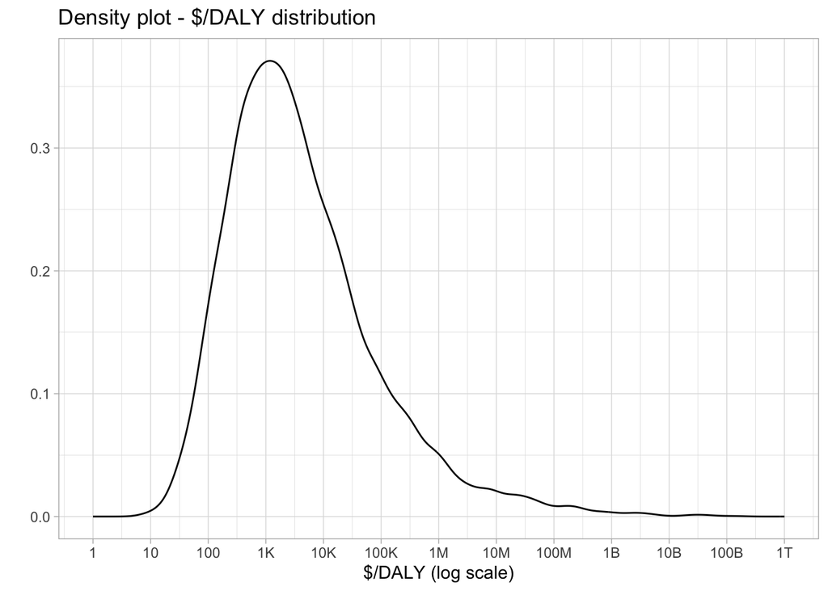

```r
fig_a21_dollars_per_daly_nonstunning
```

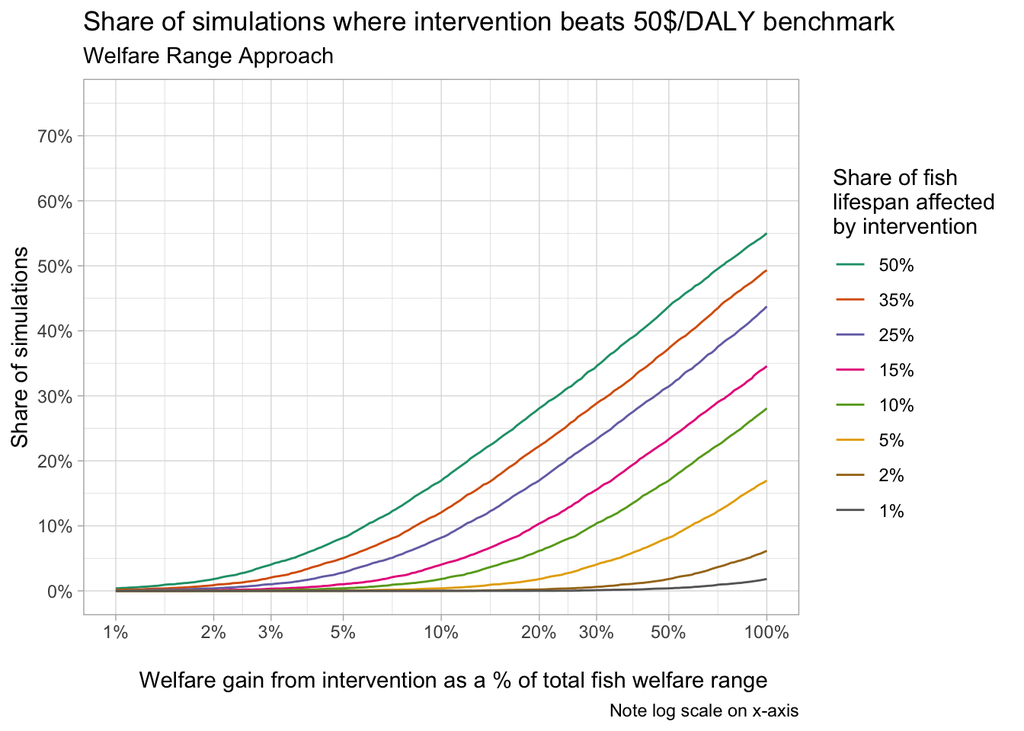

```r
fig_a22_50benchmark_wv_nonstunning
```

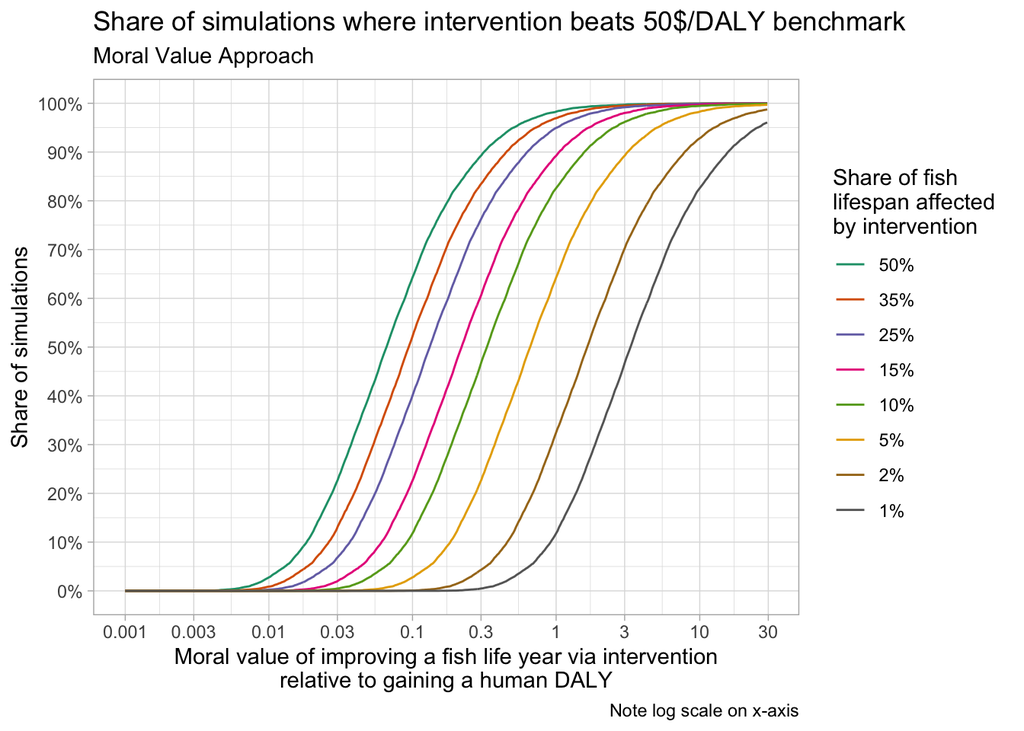

```r
fig_a23_50benchmark_mv_nonstunning
```

```r
save_chart("fig_a21_dollars_per_daly_nonstunning .png",fig_a21_dollars_per_daly_nonstunning )
save_chart("fig_a22_50benchmark_wv_nonstunning.png",fig_a22_50benchmark_wv_nonstunning)
save_chart("fig_a23_50benchmark_mv_nonstunning.png",fig_a23_50benchmark_mv_nonstunning)
save_table(tab_a22_impact_per_dollar_nonstunning,"tab_a22_impact_per_dollar_nonstunning.html")
```

# Sensitivity to DALY share of welfare range assumption

I now run a sensitivity analysis to see how the results might differ if:

- Fish welfare range (relative to humans) was double that used in the baseline analysis
- Averting a DALY would be equivalent to raising human welfare by 10% of human welfare range for a year (rather than 50%, as per baseline analysis).

Core calculation code

```r
share_wr_alt <- function(xvar,fishlifeshare,bar) {
  mean(bar>
      (1/
        (xvar*
        fypd*
        fishlifeshare*
        salmon_wr_alt/
        DALY_share_of_welfare_range_alt
        )))
}
```

Combinations over which to run analysis

```r
share_sims_calculation_grid_alt <-  expand_grid(
                                    xvar=wr_table_values,
                                    bar=50,
                                    fishlifeshare=fishlifeshare_values)
```

Run calculations

```r
share_sims_results_table_alt <-
# Generate one row for unique combination of xvar_values and scenario lists
  share_sims_calculation_grid_alt %>%
# Core calcualtions using share_mv and share_wr calculation functions
    rowwise() %>%
    mutate(
      base=share_wr(xvar,fishlifeshare,bar),
      alt=share_wr_alt(xvar,fishlifeshare,bar)
    ) %>%
  distinct() %>%
  mutate(
    fishlifeshare=factor(fishlifeshare,labels=paste0(fishlifeshare*100,"%"))) %>%
  select(-bar) %>%
  pivot_longer(
    cols=c(base,alt),
    names_to="daly_assumption",
    values_to="share_of_sims")
```

Format output

```r
alt_table_comparison <- function(assumption) {
share_sims_results_table_alt %>%
 filter(daly_assumption==assumption) %>%
 select(-daly_assumption) %>%
  pivot_wider(
    id_cols=xvar,
    names_from=c(fishlifeshare),
    values_from=share_of_sims) %>%
  arrange(xvar) %>%
  gt() %>%
  fmt_percent(decimals=1) %>%
  cols_label(
    xvar="Welfare gain from intervention as a share of fish welfare range") %>%
  tab_spanner(
    label="Share of fish lifespan affected by intervention",
    columns=-1
      )
}
```

Generate output tables

```r
alt_table_comparison("base") %>%
  tab_header(title="Share of simulations beating $50/DALY - baseline assumptions")
```

Share of simulations beating $50/DALY - baseline assumptions

| Welfare gain from intervention as a share of fish welfare range | Share of fish lifespan affected by intervention 1% | Share of fish lifespan affected by intervention 2% | Share of fish lifespan affected by intervention 5% | Share of fish lifespan affected by intervention 10% | Share of fish lifespan affected by intervention 15% | Share of fish lifespan affected by intervention 25% | Share of fish lifespan affected by intervention 35% | Share of fish lifespan affected by intervention 50% |
| --- | --- | --- | --- | --- | --- | --- | --- | --- |
| 0.1% | 0.0% | 0.0% | 0.0% | 0.0% | 0.0% | 0.0% | 0.0% | 0.0% |
| 1.0% | 0.0% | 0.0% | 0.0% | 0.0% | 0.0% | 0.0% | 0.2% | 0.4% |
| 2.5% | 0.0% | 0.0% | 0.0% | 0.0% | 0.2% | 0.7% | 1.4% | 2.8% |
| 10.0% | 0.0% | 0.0% | 0.4% | 1.8% | 4.0% | 8.2% | 12.1% | 17.0% |
| 15.0% | 0.0% | 0.1% | 1.0% | 4.0% | 7.2% | 13.0% | 17.8% | 23.3% |
| 35.0% | 0.2% | 0.9% | 5.0% | 12.1% | 17.8% | 25.9% | 31.2% | 37.3% |
| 50.0% | 0.4% | 1.8% | 8.2% | 17.0% | 23.3% | 31.4% | 37.3% | 43.8% |
| 75.0% | 1.0% | 4.0% | 13.0% | 23.3% | 29.8% | 38.6% | 44.6% | 50.5% |
| 90.0% | 1.5% | 5.3% | 15.6% | 26.3% | 32.7% | 41.7% | 47.5% | 53.4% |
| 100.0% | 1.8% | 6.2% | 17.0% | 28.1% | 34.6% | 43.8% | 49.3% | 55.0% |

```r
alt_table_comparison("alt") %>%
  tab_header(title="Share of simulations beating $50/DALY - alternative assumptions")
```

Share of simulations beating $50/DALY - alternative assumptions

| Welfare gain from intervention as a share of fish welfare range | Share of fish lifespan affected by intervention 1% | Share of fish lifespan affected by intervention 2% | Share of fish lifespan affected by intervention 5% | Share of fish lifespan affected by intervention 10% | Share of fish lifespan affected by intervention 15% | Share of fish lifespan affected by intervention 25% | Share of fish lifespan affected by intervention 35% | Share of fish lifespan affected by intervention 50% |
| --- | --- | --- | --- | --- | --- | --- | --- | --- |
| 0.1% | 0.0% | 0.0% | 0.0% | 0.0% | 0.0% | 0.0% | 0.2% | 0.4% |
| 1.0% | 0.0% | 0.0% | 0.4% | 1.8% | 4.0% | 8.2% | 12.1% | 17.0% |
| 2.5% | 0.0% | 0.4% | 2.8% | 8.2% | 13.0% | 20.6% | 25.9% | 31.4% |
| 10.0% | 1.8% | 6.2% | 17.0% | 28.1% | 34.6% | 43.8% | 49.3% | 55.0% |
| 15.0% | 4.0% | 10.3% | 23.3% | 34.6% | 41.7% | 50.5% | 55.9% | 60.9% |
| 35.0% | 12.1% | 22.3% | 37.3% | 49.3% | 55.9% | 62.9% | 67.2% | 71.1% |
| 50.0% | 17.0% | 28.1% | 43.8% | 55.0% | 60.9% | 67.5% | 71.1% | 74.6% |
| 75.0% | 23.3% | 34.6% | 50.5% | 60.9% | 66.1% | 71.9% | 75.0% | 78.1% |
| 90.0% | 26.3% | 37.9% | 53.4% | 63.2% | 68.3% | 73.6% | 76.6% | 79.6% |
| 100.0% | 28.1% | 39.5% | 55.0% | 64.5% | 69.3% | 74.6% | 77.6% | 80.4% |